# Eyes: normal mixture model for microspectophotometric records

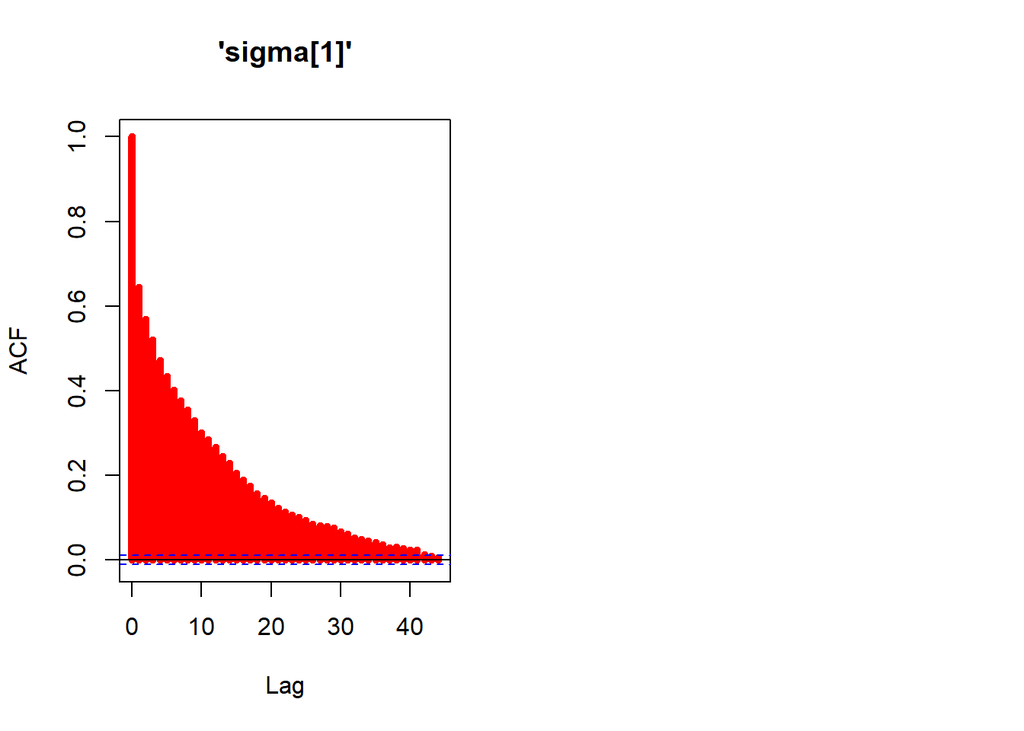

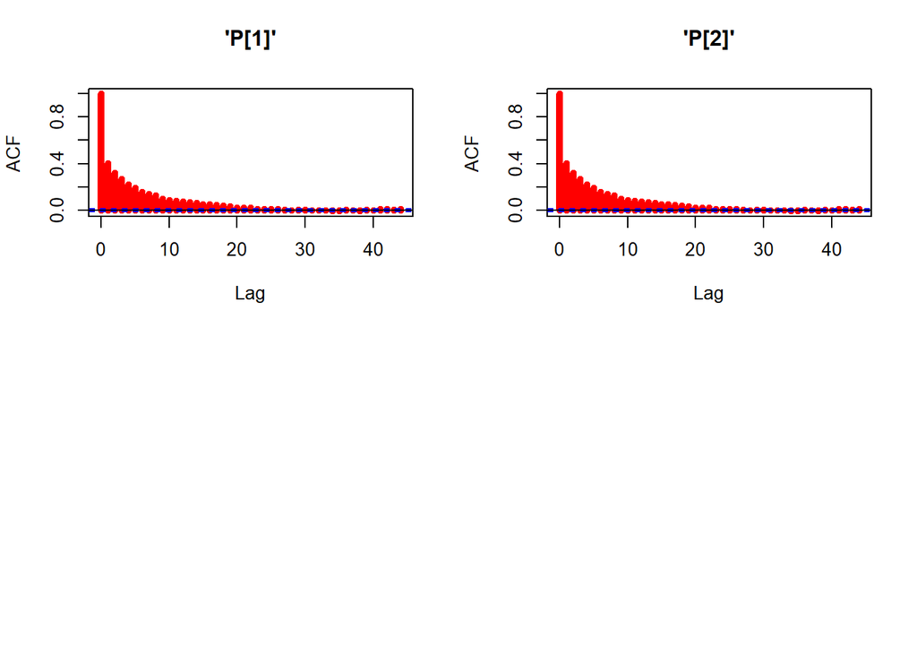

As last step, I computed the MLE.

```
## [1] "Estimated parameters"
```

```
## [1] "Mu"
```

```
## [1] 537.8773 550.7064
```

```
## [1] "Sigma"
```

```
## [1] 3.01572
```

```
## [1] "Weights"
```

```
## [1] 0.7150197 0.2849803
```

```
## [1] "Likelihood"
```

```
## [1] -152.1011
```

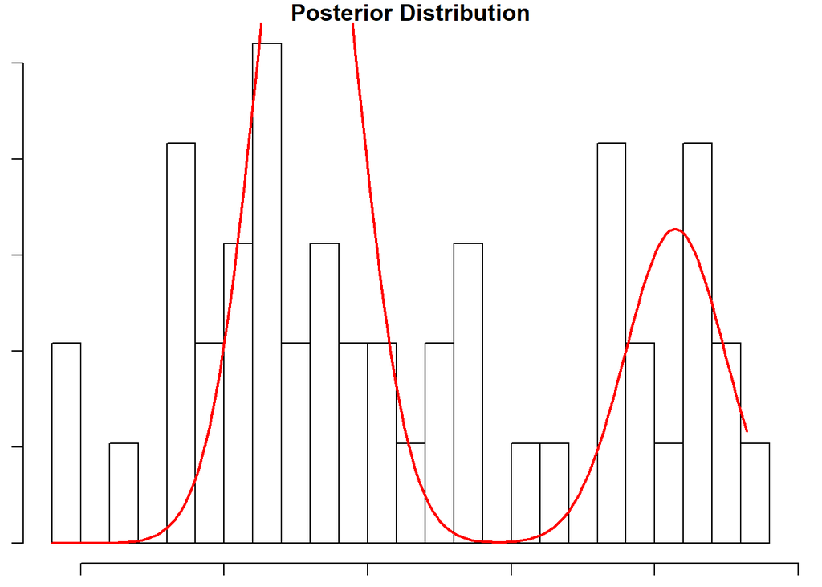

[output not shown]

DIC and Likelihood estimated with BUG’s results:

```
## $DIC
## [1] 317.8169
##
## $P
## [1] 3.961704
##
## $L
## [1] -154.9467
```

DIC and Likelihood estimated with on my own Gibbs’s results:

```
## $DIC
## [1] 318.216
##
## $P
## [1] 4.145541
##
## $L
## [1] -154.9625
```

As we can see the Winbugs gives the almost same results as my own implementation of Gibbs, comparing this results with Bowmaker et al. I can conclude that both methods return right values for the parameters.